# Testing values of n-grams and similarity scores

Lincoln Mullen

```r
knitr::opts_chunk$set(echo = TRUE)
load("cache/corpus-lsh.rda")
library(dplyr)
```

```r
library(textreuse)
library(ggplot2)
library(ggrepel)
library(tidyr)
```

We are using n-grams as the tokens for detecting document similarity. We want to know for n-grams or skip n-grams, which values of `n` and `k` are optimal. To test these we are going to use four sections from the codes of civil procedure. They all have the same legal effect of abolishing the distinction between law and equity and creating the form of civil action. But they do with this with more or less linguistic similarity to the original New York provision. WA1855 has the same structure but nearly completely changes the wording. CA1851 has only the second half of the provision. FL1870 borrows the provision mostly unchanged. And as a kind of a control, we will include a random section from TX1855 with no connection to the original provision.

The text of the sections.

```r
NY <- sections[["NY1850-006060"]] %>% content()
NY
```

```
## 554. The distinction between actions at law and suits in equity, and the forms of all such actions and suits, heretofore existing, are abolished; and, there shall be in this state, hereafter, but one form of action, for the enforcement or protection of private rights and the redress or prevention…
```

```r
WA <- sections[["WA1855-000020"]] %>% content()
WA
```

```
## 1. Be it enacted by the Legislative Assembky of the Territory
## of Washington, That all common law forms of action, and all distinctions between law and equity are hereby abolished, and hereafter
## there shall bein this territory but one form of action, to establish and enforce private rights, which shall be called a civil action.
```

```r
CA <- sections[["CA1851-000030"]] %>% content()
CA
```

```
## 1. There shall be in this State but one form of Civil Action, for
## the enforcement or protection of private right, and the redress or prevention of private wrongs.
```

```r
FL <- sections[["FL1870-000600"]] %>% content()
FL
```

```
## 49. The distinction, between actions at law and suits in equity,
## and the forms of all such actions and suits heretofore existing,
## are abolished; and there shall be in this State hereafter but one
##
## form of action for the enforcement or protection of private
## rights and the redress of private wrongs, which shall be denominated a civil action.
```

```r
control <- sections[["TX1855-005820"]] %>% content()
control
```

```
## 505.  In a suit for the recovery of money only, the defendant having answered, may serve upon the plaintifff or his attorney, an offer in writing, that, if he fail in his defense, the amount of the recovery shall be assessed at a specified sum.  If the plaintifff accept the offer and give notice …
```

Now a comparison of the similarity among the sections using 5-grams.

```r
id <- c("NY1850-006060", "WA1855-000020", "CA1851-000030", "FL1870-000600",
        "TX1855-005820")
sections_subset <- sections[id]
m <- pairwise_compare(sections_subset, jaccard_similarity) %>% round(2)
m[-5 , -1]
```

```
##               WA1855-000020 CA1851-000030 FL1870-000600 TX1855-005820
## NY1850-006060          0.01          0.14          0.80             0
## WA1855-000020            NA          0.00          0.01             0
## CA1851-000030            NA            NA          0.08             0
## FL1870-000600            NA            NA            NA             0
```

Just to be sure, verify that tokenizing with skip n-grams for a value of `k = 0` is the same thing as tokenizing with just n-grams.

```r
all(tokenize_ngrams(WA, n = 5) == tokenize_skip_ngrams(WA, n = 5, k = 0))
```

```
## [1] TRUE
```

A function to calculate the Jaccard similarity for arbitrary values of `n` and `k`.

```r
similarity <- function(x, y, n, k) {
  jaccard_similarity(tokenize_skip_ngrams(x, n = n, k = k),
                     tokenize_skip_ngrams(y, n = n, k = k))
}
similarity_safe <- failwith(NA_real_, f = similarity, quiet = TRUE)
```

The current similarity scores we are working with for `n = 5`, `k = 0`.

```r
current_values <- data_frame(
  cf = c("WA", "CA", "FL", "control"),
  current = c(
    similarity(WA, NY, n = 5, k = 0),
    similarity(CA, NY, n = 5, k = 0),
    similarity(FL, NY, n = 5, k = 0),
    similarity(control, NY, n = 5, k = 0)
  )
)
```

Calculate the similarity scores for all combinations of `n` and `k`.

```r
comparisons <-  expand.grid(n = 2:8, k = 0:4,
                                   cf = c("WA", "CA", "FL", "control"),
                                   stringsAsFactors = FALSE) %>%
  rowwise() %>%
  mutate(score = similarity_safe(NY, get(cf), n = n, k = k)) %>%
  left_join(current_values) %>%
  mutate(ratio = score / current,
         score = round(score, 3),
         current = round(current, 3),
         ratio = round(ratio, 3),
         cf = factor(cf, levels = c("WA", "CA", "FL", "control"))) %>%
  ungroup()
```

Make a plot of the similarity scores. (Note that the y-axes vary.)

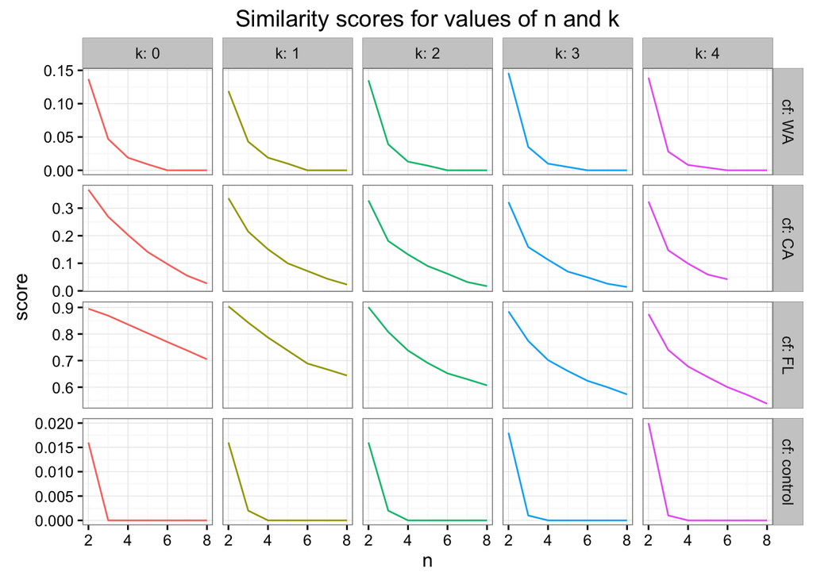

```r
ggplot(comparisons, aes(x = n, y = score, color = as.factor(k))) +
  geom_line() +
  facet_grid(cf ~ k, labeller = label_both, scales = "free_y") +
  theme_bw() +
  guides(color = FALSE) +
  ggtitle("Similarity scores for values of n and k")
```

This is basically what we would expect. Increasing values of `n` and increasing values of `k` both decrease the Jaccard score. It is not simply the case that a high Jaccard similarity score is a good thing, because that creates more false positives. We can rule out any value of `n` or `k` which creates a similarity score for the control which is appreciably above 0. So we can immediately rule out values of `n` that are less than 3 when `k` is 0. The question is which values of `n` and `k` create the highest value for the WA section that is better than the current Jaccard similarity score (approx. 0.01) without creating more false positives.

To put that logic into a table, these are the mostly likely to be useful settings of `n` and `k`. First the most useful settings optimizing for the highest values for WA.

```r
valid_params <- comparisons %>%
  select(-current, -ratio) %>%
  spread(cf, score) %>%
  filter(control < 0.02,
         WA >= 0.009)
valid_params %>%
  arrange(desc(WA))
```

```
## Source: local data frame [15 x 6]
##
##        n     k    WA    CA    FL control
##    (int) (int) (dbl) (dbl) (dbl)   (dbl)
## 1      2     3 0.146 0.322 0.885   0.018
## 2      2     0 0.137 0.367 0.895   0.016
## 3      2     2 0.135 0.328 0.901   0.016
## 4      2     1 0.119 0.336 0.904   0.016
## 5      3     0 0.047 0.269 0.869   0.000
## 6      3     1 0.043 0.215 0.843   0.002
## 7      3     2 0.039 0.181 0.808   0.002
## 8      3     3 0.035 0.159 0.774   0.001
## 9      3     4 0.028 0.147 0.740   0.001
## 10     4     0 0.019 0.203 0.836   0.000
## 11     4     1 0.019 0.151 0.787   0.000
## 12     4     2 0.013 0.132 0.738   0.000
## 13     4     3 0.010 0.113 0.702   0.000
## 14     5     1 0.010 0.100 0.738   0.000
## 15     5     0 0.009 0.141 0.803   0.000
```

Now optimizing for the highest ratio between WA and the control.

```r
valid_params %>%
  mutate(ratio_WA_to_control = WA / control) %>%
  arrange(desc(ratio_WA_to_control), desc(WA))
```

```
## Source: local data frame [15 x 7]
##
##        n     k    WA    CA    FL control ratio_WA_to_control
##    (int) (int) (dbl) (dbl) (dbl)   (dbl)               (dbl)
## 1      3     0 0.047 0.269 0.869   0.000                 Inf
## 2      4     0 0.019 0.203 0.836   0.000                 Inf
## 3      4     1 0.019 0.151 0.787   0.000                 Inf
## 4      4     2 0.013 0.132 0.738   0.000                 Inf
## 5      4     3 0.010 0.113 0.702   0.000                 Inf
## 6      5     1 0.010 0.100 0.738   0.000                 Inf
## 7      5     0 0.009 0.141 0.803   0.000                 Inf
## 8      3     3 0.035 0.159 0.774   0.001           35.000000
## 9      3     4 0.028 0.147 0.740   0.001           28.000000
## 10     3     1 0.043 0.215 0.843   0.002           21.500000
## 11     3     2 0.039 0.181 0.808   0.002           19.500000
## 12     2     0 0.137 0.367 0.895   0.016            8.562500
## 13     2     2 0.135 0.328 0.901   0.016            8.437500
## 14     2     3 0.146 0.322 0.885   0.018            8.111111
## 15     2     1 0.119 0.336 0.904   0.016            7.437500
```

We can try to plot that relationship between the control and WA for different values of `n` and `k`.

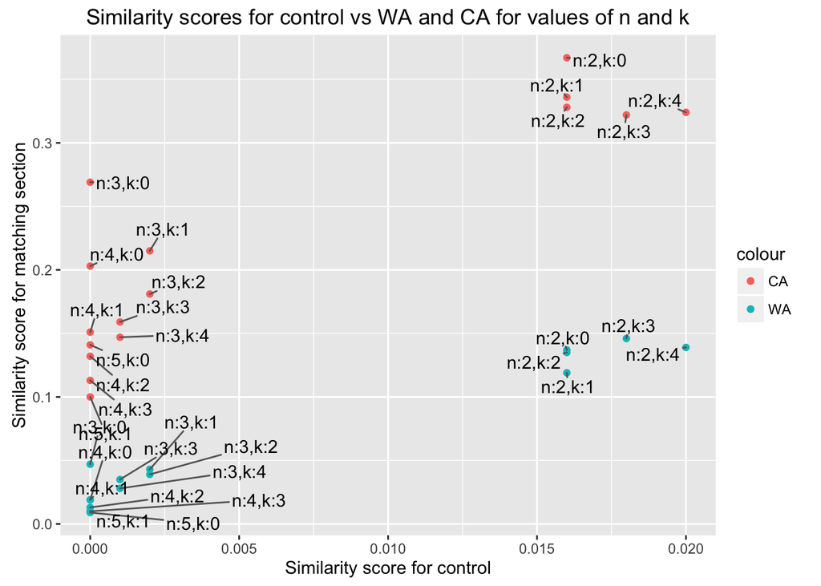

```r
comparisons %>%
  select(-current, -ratio) %>%
  spread(cf, score) %>%
  filter(WA >= 0.009) %>%
  ggplot(aes(x = control, label = paste0("n:", n, ",k:", k))) +
  geom_point(aes(y = WA, color = "WA")) +
  geom_point(aes(y = CA, color = "CA")) +
  geom_text_repel(aes(y = WA)) +
  geom_text_repel(aes(y = CA)) +
  labs(title = "Similarity scores for control vs WA and CA for values of n and k",
       x = "Similarity score for control",
       y = "Similarity score for matching section")
```

It would seem like there are several choices that can increase the similarity score of Washington. The safest choice is `n = 3, k = 0`. The riskiest choice is probably `n = 2, k = 0`, though `n = 2, k = 3` might also work. We can discard the option of `n = 2, k = 3` since that will create many more tokens than `n = 2, k = 0` (about 4 times as many) for not much gain. We might be best off using tri-grams.